# 06_analysis_scatterplot

Julie Bruun Brockhoff (s204519), Cecilie Kejlberg Leth (s204584), Amalie Drud Nielsen (s204560), Chrysillis Hellemann Polhaus (s153664), Lise Lotte Eriksen (s154123)

### Load packages

```r
library(tidyverse)
library(here)
library(readr)
library(scales)
```

### Load data

```r
data <- read_tsv(file = here("data/03_dat_aug.tsv"))
```

### Regression models for up- and down-regulated OVCAR3 DEGs

Two separate regression models comparing the OVCAR3 cell line at baseline and after HERV-K knock-out for both up-regulated DEGs and down-regulated DEGs.

```r
#Regression model for up-regulated DEGs
Equation_OVCAR3_UP <- data |>
  select(OVCAR3_MOCK,
         OVCAR3_KO,
         DEG_OVCAR3) |>
  filter(DEG_OVCAR3 == "Upregulated") |>
  lm(formula = OVCAR3_KO ~ OVCAR3_MOCK)

summary(Equation_OVCAR3_UP)
```

```
##
## Call:
## lm(formula = OVCAR3_KO ~ OVCAR3_MOCK, data = filter(select(data,
##     OVCAR3_MOCK, OVCAR3_KO, DEG_OVCAR3), DEG_OVCAR3 == "Upregulated"))
##
## Residuals:
##    Min     1Q Median     3Q    Max
## -54727    -11     -8     -1  56718
##
## Coefficients:
##              Estimate Std. Error t value Pr(>|t|)
## (Intercept) 13.836817  20.360780    0.68    0.497
## OVCAR3_MOCK  5.026404   0.009379  535.91   <2e-16 ***
## ---
## Signif. codes:  0 '***' 0.001 '**' 0.01 '*' 0.05 '.' 0.1 ' ' 1
##
## Residual standard error: 1321 on 4210 degrees of freedom
## Multiple R-squared:  0.9856, Adjusted R-squared:  0.9855
## F-statistic: 2.872e+05 on 1 and 4210 DF,  p-value: < 2.2e-16
```

```r
#Regression model for down-regulated DEGs
Equation_OVCAR3_DOWN <- data |>
  select(OVCAR3_MOCK,
         OVCAR3_KO,
         DEG_OVCAR3) |>
  filter(DEG_OVCAR3 == "Downregulated") |>
  lm(formula = OVCAR3_KO ~ OVCAR3_MOCK)

summary(Equation_OVCAR3_DOWN)
```

```
##
## Call:
## lm(formula = OVCAR3_KO ~ OVCAR3_MOCK, data = filter(select(data,
##     OVCAR3_MOCK, OVCAR3_KO, DEG_OVCAR3), DEG_OVCAR3 == "Downregulated"))
##
## Residuals:
##     Min      1Q  Median      3Q     Max
## -3472.4     3.5     5.0    41.6  4814.9
##
## Coefficients:
##              Estimate Std. Error t value Pr(>|t|)
## (Intercept) -5.439892  11.851489  -0.459    0.646
## OVCAR3_MOCK  0.181668   0.001586 114.520   <2e-16 ***
## ---
## Signif. codes:  0 '***' 0.001 '**' 0.01 '*' 0.05 '.' 0.1 ' ' 1
##
## Residual standard error: 312.1 on 764 degrees of freedom
## Multiple R-squared:  0.945,  Adjusted R-squared:  0.9449
## F-statistic: 1.311e+04 on 1 and 764 DF,  p-value: < 2.2e-16
```

```r
#Regression model for neutral DEGs
Equation_OVCAR3_NEU <- data |>
  select(OVCAR3_MOCK,
         OVCAR3_KO,
         DEG_OVCAR3) |>
  filter(DEG_OVCAR3 == "Neutral") |>
  lm(formula = OVCAR3_KO ~ OVCAR3_MOCK)

summary(Equation_OVCAR3_NEU)
```

```
##
## Call:
## lm(formula = OVCAR3_KO ~ OVCAR3_MOCK, data = filter(select(data,
##     OVCAR3_MOCK, OVCAR3_KO, DEG_OVCAR3), DEG_OVCAR3 == "Neutral"))
##
## Residuals:
##     Min      1Q  Median      3Q     Max
## -131945     104     463     469  397430
##
## Coefficients:
##               Estimate Std. Error t value Pr(>|t|)
## (Intercept) -4.680e+02  2.718e+01  -17.22   <2e-16 ***
## OVCAR3_MOCK  1.744e+00  8.645e-03  201.72   <2e-16 ***
## ---
## Signif. codes:  0 '***' 0.001 '**' 0.01 '*' 0.05 '.' 0.1 ' ' 1
##
## Residual standard error: 4049 on 23060 degrees of freedom
## Multiple R-squared:  0.6383, Adjusted R-squared:  0.6383
## F-statistic: 4.069e+04 on 1 and 23060 DF,  p-value: < 2.2e-16
```

### Scatter plot of KO vs baseline DEGs in OVCAR3

A scatter plot is done to visualise the comparison of the OVCAR3 cell line at baseline and after HERV-K knock-out for both up-regulated DEGs, down-regulated DEGs and neutral DEGs from above.

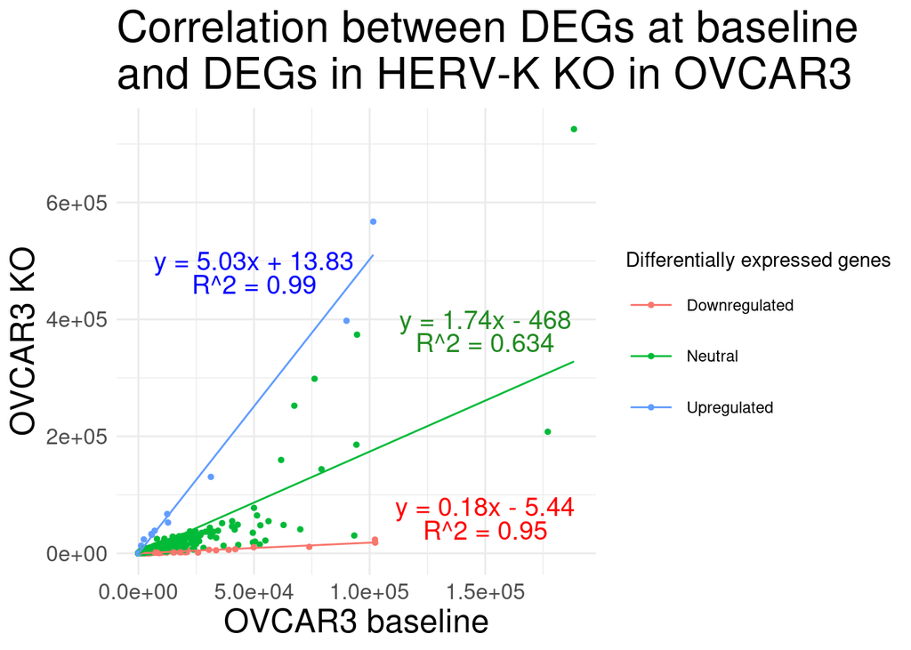

```r
scatter_plot_OVCAR3 <- data |>
  ggplot(mapping = aes(x = OVCAR3_MOCK,
                       y = OVCAR3_KO,
                       color = DEG_OVCAR3)) +
  geom_point(size = 1) +
  geom_smooth(method = "lm",
              linewidth = 0.5,
              se = FALSE) +
  labs(title = "Correlation between DEGs at baseline \nand DEGs in HERV-K KO in OVCAR3",
       x = "OVCAR3 baseline",
       y = "OVCAR3 KO",
       color = "Differentially expressed genes") +
  scale_x_continuous(labels = scientific) +
  scale_y_continuous(labels = scientific) +
  theme_minimal() +
  theme(plot.title = element_text(size = 24),
        axis.title = element_text(size = 18),
        axis.text = element_text(size = 12),
        legend.key.size = unit(1,"cm")) +
  annotate("text",
           x = 150000, y = 80000,
           size = 5,
           label = "y = 0.18x - 5.44",
           color = "red") +
  annotate("text",
           x = 150000, y = 40000,
           size = 5,
           label = "R^2 = 0.95",
           color = "red") +
  annotate("text",
           x = 50000, y = 500000,
           size = 5,
           label = "y = 5.03x + 13.83",
           color = "blue") +
  annotate("text",
           x = 50000, y = 460000,
           size = 5,
           label = "R^2 = 0.99",
           color = "blue") +
  annotate("text",
           x = 150000, y = 400000,
           size = 5,
           label = "y = 1.74x - 468",
           color = "forestgreen") +
  annotate("text",
           x = 150000, y = 360000,
           size = 5,
           label = "R^2 = 0.634",
           color = "forestgreen")

scatter_plot_OVCAR3
```

For all three DEG groups (up- and down-regulated and neutral) a positive correlation is found between the OVCAR3 cells at baseline and after HERV-K KO.

The plot is saved in a png-file in the results folder:

```r
ggsave(filename = here("results/06_scatter_OVCAR3.png"),
       plot = scatter_plot_OVCAR3,
       width = 8,
       height = 5)
```

### Regression models for up- and down-regulated SKOV3 DEGs

Two separate regression models comparing the SKOV3 cell line at baseline and after HERV-K knock-out for both up-regulated DEGs and down-regulated DEGs.

```r
#Regression model for up-regulated DEGs
Equation_SKOV3_UP <- data |>
  select(SKOV3_MOCK,
         SKOV3_KO,
         DEG_SKOV3) |>
  filter(DEG_SKOV3 == "Upregulated") |>
  lm(formula = SKOV3_KO ~ SKOV3_MOCK)

summary(Equation_SKOV3_UP)
```

```
##
## Call:
## lm(formula = SKOV3_KO ~ SKOV3_MOCK, data = filter(select(data,
##     SKOV3_MOCK, SKOV3_KO, DEG_SKOV3), DEG_SKOV3 == "Upregulated"))
##
## Residuals:
##     Min      1Q  Median      3Q     Max
## -4.1684 -1.0539 -1.0539 -0.0539 14.9461
##
## Coefficients:
##             Estimate Std. Error t value Pr(>|t|)
## (Intercept)   4.0539     0.1287   31.51   <2e-16 ***
## SKOV3_MOCK    5.0127     0.1661   30.18   <2e-16 ***
## ---
## Signif. codes:  0 '***' 0.001 '**' 0.01 '*' 0.05 '.' 0.1 ' ' 1
##
## Residual standard error: 2.082 on 268 degrees of freedom
## Multiple R-squared:  0.7727, Adjusted R-squared:  0.7718
## F-statistic: 910.9 on 1 and 268 DF,  p-value: < 2.2e-16
```

```r
#Regression model for down-regulated DEGs
Equation_SKOV3_DOWN <- data |>
  select(SKOV3_MOCK,
         SKOV3_KO,
         DEG_SKOV3) |>
  filter(DEG_SKOV3 == "Downregulated") |>
  lm(formula = SKOV3_KO ~ SKOV3_MOCK)

summary(Equation_SKOV3_DOWN)
```

```
##
## Call:
## lm(formula = SKOV3_KO ~ SKOV3_MOCK, data = filter(select(data,
##     SKOV3_MOCK, SKOV3_KO, DEG_SKOV3), DEG_SKOV3 == "Downregulated"))
##
## Residuals:
##     Min      1Q  Median      3Q     Max
## -68.270   0.038   0.246   0.454   7.287
##
## Coefficients:
##               Estimate Std. Error t value Pr(>|t|)
## (Intercept) -1.0788438  0.0817257   -13.2   <2e-16 ***
## SKOV3_MOCK   0.2081989  0.0004673   445.5   <2e-16 ***
## ---
## Signif. codes:  0 '***' 0.001 '**' 0.01 '*' 0.05 '.' 0.1 ' ' 1
##
## Residual standard error: 2.471 on 918 degrees of freedom
## Multiple R-squared:  0.9954, Adjusted R-squared:  0.9954
## F-statistic: 1.985e+05 on 1 and 918 DF,  p-value: < 2.2e-16
```

```r
#Regression model for neutral DEGs
Equation_SKOV3_NEU <- data |>
  select(SKOV3_MOCK,
         SKOV3_KO,
         DEG_SKOV3) |>
  filter(DEG_SKOV3 == "Neutral") |>
  lm(formula = SKOV3_KO ~ SKOV3_MOCK)

summary(Equation_SKOV3_NEU)
```

```
##
## Call:
## lm(formula = SKOV3_KO ~ SKOV3_MOCK, data = filter(select(data,
##     SKOV3_MOCK, SKOV3_KO, DEG_SKOV3), DEG_SKOV3 == "Neutral"))
##
## Residuals:
##    Min     1Q Median     3Q    Max
## -24499    -20    -19     -8  39326
##
## Coefficients:
##              Estimate Std. Error t value Pr(>|t|)
## (Intercept) 1.938e+01  3.083e+00   6.285 3.32e-10 ***
## SKOV3_MOCK  6.633e-01  7.277e-04 911.503  < 2e-16 ***
## ---
## Signif. codes:  0 '***' 0.001 '**' 0.01 '*' 0.05 '.' 0.1 ' ' 1
##
## Residual standard error: 495.6 on 26848 degrees of freedom
## Multiple R-squared:  0.9687, Adjusted R-squared:  0.9687
## F-statistic: 8.308e+05 on 1 and 26848 DF,  p-value: < 2.2e-16
```

### Scatter plot of KO vs baseline DEGs in SKOV3

A scatter plot is done to visualise the comparison of the SKOV3 cell line at baseline and after HERV-K knock-out for both up-regulated DEGs, down-regulated DEGs and neutral DEGs from above.

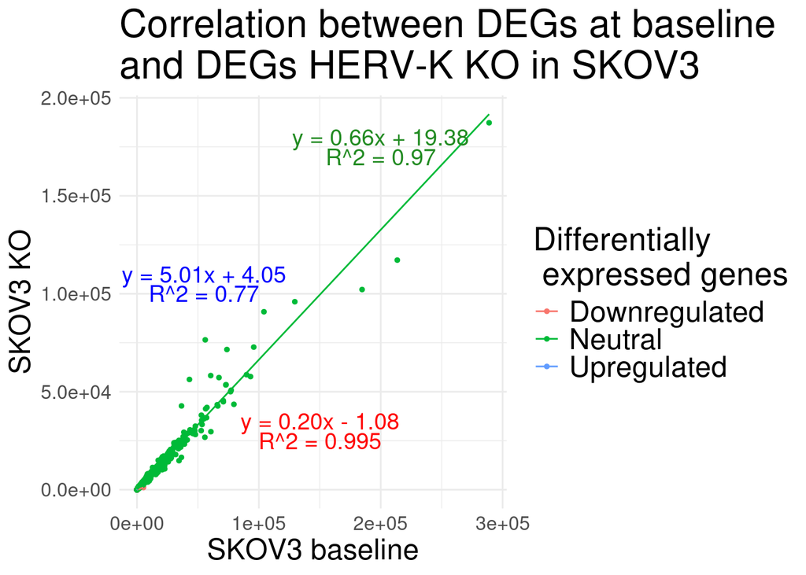

```r
#Scatterplot showing all data DEGs
scatter_plot_SKOV3 <- data |>
  ggplot(mapping = aes(x = SKOV3_MOCK,
                       y = SKOV3_KO,
                       color = DEG_SKOV3)) +
  geom_point(size = 1) +
  geom_smooth(method = "lm",
              se = FALSE,
              linewidth = 0.5) +
  labs(title = "Correlation between DEGs at baseline \nand DEGs HERV-K KO in SKOV3",
       x = "SKOV3 baseline",
       y = "SKOV3 KO",
       color = "Differentially\n expressed genes") +
  scale_x_continuous(labels = scientific) +
  scale_y_continuous(labels = scientific) +
  theme_minimal() +
  theme(plot.title = element_text(size = 24),
        axis.title = element_text(size = 18),
        axis.text = element_text(size = 12),
        legend.title = element_text(size = 20),
        legend.text = element_text(size = 18))+
  annotate("text",
           x = 55000, y = 110000,
           size = 5,
           label = "y = 5.01x + 4.05",
           color = "blue") +
  annotate("text",
           x = 55000, y = 100000,
           size = 5,
           label = "R^2 = 0.77",
           color = "blue") +
  annotate("text",
           x = 150000, y = 35000,
           size = 5,
           label = "y = 0.20x - 1.08",
           color = "red") +
  annotate("text",
           x = 150000, y = 25000,
           size = 5,
           label = "R^2 = 0.995",
           color = "red") +
  annotate("text",
           x = 200000, y = 180000,
           size = 5,
           label = "y = 0.66x + 19.38",
           color = "forestgreen") +
  annotate("text",
           x = 200000, y = 170000,
           size = 5,
           label = "R^2 = 0.97",
           color = "forestgreen")

scatter_plot_SKOV3
```

As expected, a clear positive correlation is seen for the neutral DEGs in SKOV3.

The plot is saved in a png-file in the results folder:

```r
ggsave(filename = here("results/06_scatter_SKOV3.png"),
       plot = scatter_plot_SKOV3,
       width = 8,
       height = 5)
```

### Scatter plot of KO vs baseline DEGs in SKOV3 with changed axis

In the above correlation analysis, it is not possible to see the down-regulated and up-regulated DEGs in SKOV3, as their relative expression is low. The same correlation analysis is performed, but with changed axis making it possible to see the up- and down-regulated DEGs.

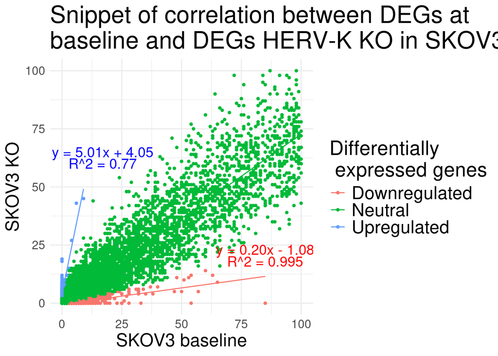

```r
#Scatterplot with chosen axis FIX:
scatter_plot_SKOV3_fixed <- data |>
  ggplot(mapping = aes(x = SKOV3_MOCK,
                       y = SKOV3_KO,
                       color = DEG_SKOV3)) +
  geom_point(size = 1) +
  geom_smooth(method = "lm",
              se = FALSE,
              linewidth = 0.5) +
  theme_minimal() +
  theme(plot.title = element_text(size = 24),
        axis.title = element_text(size = 18),
        axis.text = element_text(size = 12),
        legend.title = element_text(size = 20),
        legend.text = element_text(size = 18),
        legend.key = element_rect(color = "white"))+
  labs(title = "Snippet of correlation between DEGs at \nbaseline and DEGs HERV-K KO in SKOV3",
       x = "SKOV3 baseline",
       y = "SKOV3 KO",
       color = "Differentially\n expressed genes") +
  scale_x_continuous(labels = scientific) +
  scale_y_continuous(labels = scientific) +
  xlim(0, 100) +
  ylim(0, 100) +
  annotate("text",
           x = 17, y = 65,
           size = 5,
           label = "y = 5.01x + 4.05",
           color = "blue") +
  annotate("text",
           x = 17, y = 60,
           size = 5,
           label = "R^2 = 0.77",
           color = "blue") +
  annotate("text",
           x = 85, y = 23,
           size = 5,
           label = "y = 0.20x - 1.08",
           color = "red") +
  annotate("text",
           x = 85, y = 18,
           size = 5,
           label = "R^2 = 0.995",
           color = "red")
scatter_plot_SKOV3_fixed
```

When changing the visible area, we can see similar results as seen for OVCAR3. A positive correlation is found between the SKOV3 cells at baseline and after HERV-K KO.

The plot is saved in a png-file in the results folder: